# Demografi: opgaver 2

Johan Sebastian Ohlendorff

# Opgave 1

## Delspørgsmål 1

Hvilke enheder har hhv., folketal, middelfolketal, risikotid og mortalitetsrate?

- Vi antager at tidsenheden er i år.
- **folketal:** *antal personer*: antal til et bestemt tidspunkt.
- **middelfolketal:** *antal personår / år = antal personer*: det gennemsnittetlige antal personer i en periode.
- **risikotid:**: *antal personår* i en periode.
- **rate:**: *antal døde/personår* i en periode.

## Delspørgsmål 2

Angiv en formel som beregner middelfolketal i en situation, hvor man kender risikotid for en periode der starter i tidspunkt $t_1$ og slutter i tidspunkt $t_2$.

- $\tilde N[t_1,t_2]= R[t_1,t_2]/(t_2-t_1)$.

## Delspørgsmål 3

I perioden fra 1. januar 2008 til 31. december 2009 bidrog Bornholms befolkning samlet med 85380 personår (risikotid). Hvor stor var middelfolketallet i perioden?

- Middelfolketallet var $85380 / 2 = 42690$ personer på Bornholm i perioden fra 1. januar 2008 til 31. december 2009.

## Delspørgsmål 4 og 5

I 2008 og 2009 døde hhv. 544 og 543 personer på Bornholm. Brug disse tal og tal fra det forrige spørgsmål til at beregne mortalitetsraten for Bornholm i perioden fra 1. januar 2008 til 31. december 2009. Rapporter resultatet (i en sætning) hvor du angiver mortalitetsraten som antal døde per 1000 personår.

- Mortalitetsraten er givet som $D[t_1,t_2]/R[t_1,t_2] = (544+543 )/(85380)= 0,0127$ døde per personår, dvs. mortalitetsraten var $0,0127 \cdot 1000 = 12,7$ døde per 1000 personår i perioden fra 1. januar 2008 til 31. december 2009.

# Opgave 2

Figuren nedenfor viser en hypotetisk befolkningsgruppe bestående af kun 5 personer. Svar på følgende spørgsmål:

1. Hvor lang er perioden?
2. Hvor stort er folketallet ved starten og slutningen af perioden?
3. Beregn risikotiden eksakt for hele perioden. Angiv enheden.
4. Beregn middelfolketallet eksakt og med metode 1 og 2 for hele perioden.
5. Beregn mortalitetsrate for hele perioden. Angiv enheden.

## Figur

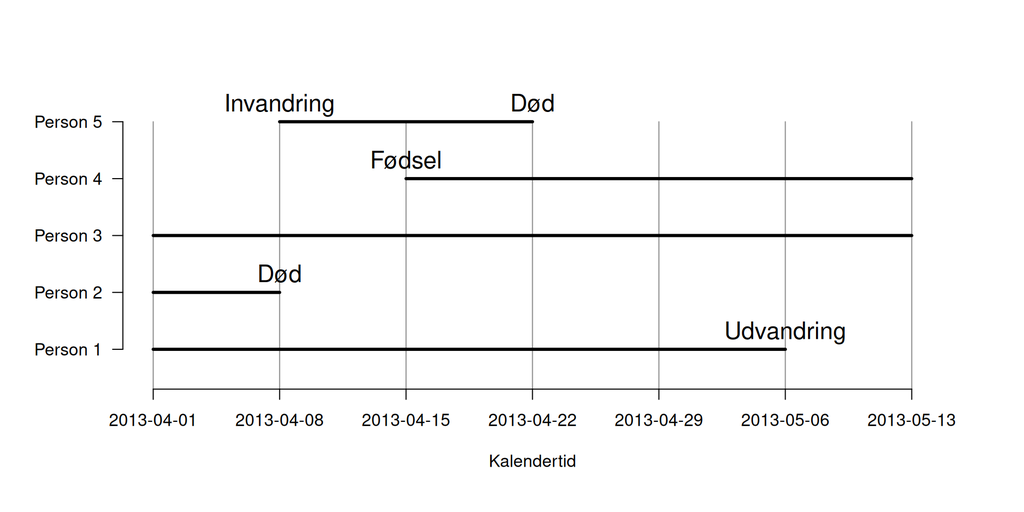

## Løsning

1. 6 uger.
2. N(1 apr 2013)= 3 personer, N(13 maj 2013) = 2 personer.
3. R[1 apr 2013, 13 maj 2013] = (2+4+6+1+5) = 18 personuger

## Løsning (fortsat)

- Eksakt: $\tilde N$[1 apr 2013, 13 maj 2013] = R[1 apr 2013, 13 maj 2013]/6 = 3 personer.
- Metode 1: $\tilde N$[22 apr 2013] = 4 (eller 3) personer.
- Metode 2: ($\tilde N$[1 apr 2013]+ N[13 maj 2013])/2 = 2,5 personer.
5. Rate[1 apr 2013, 13 maj 2013] = 2/(2+4+6+1+5) = 0,11 døde per personuge.

# Opgave 3

Sammenlign de 5 danske regioner med hensyn til mortalitetsrater i årene 2010 og 2020 ved at finde tal i statistikbanken. Rapporter resultaterne som antal døde per 1000 personår. Diskuter forskelle mellem regionerne i 2020, og forskelle i regionerne mellem 2010 og 2020.

## R kode

```r
N <- hent_data(register = "folk1a",
               tid = c("2010K3","2020K3"),
               område =c("Region Hovedstaden",
                         "Region Midtjylland",
                         "Region Nordjylland",
                         "Region Sjælland",
                         "Region Syddanmark"
                         )) ## OBS: Metode 1 til risikotid.
N <- mutate(N,TID = as.numeric(sub("K3","",TID)))
N <- rename(N,"N" = "INDHOLD")
D = hent_data(register = "fod207",
              tid = c("2010","2020"),
              område =c("Region Hovedstaden",
                        "Region Midtjylland",
                        "Region Nordjylland",
                        "Region Sjælland",
                        "Region Syddanmark"))
D <- rename(D,"D" = "INDHOLD")
M <- left_join(D,N,by = c("OMRÅDE","TID"))
M <- mutate(M,mortrate = 1000*D/N)
M <- M %>% rename("Tid" = TID,
                  "Område" = OMRÅDE,
                  "Folketal" = N,
                  "Antal døde" = D,
                  "Mortalitetsrate (døde per 1000 personår)" = mortrate)
M %>% filter(TID == 2020) ## første del af spørgsmålet
M %>% arrange(OMRÅDE, TID) ## gør det lettere at sammenligne
```

## Output og kommentarer

| Tid | Område | Antal døde | Folketal | Mortalitetsrate (døde per 1000 personår) |
| --- | --- | --- | --- | --- |
| 2020 | Region Hovedstaden | 15.591 | 1.847.289 | 8,4 |
| 2020 | Region Midtjylland | 11.516 | 1.327.410 | 8,7 |
| 2020 | Region Nordjylland | 5.953 | 589.837 | 10,1 |
| 2020 | Region Sjælland | 9.286 | 837.834 | 11,1 |
| 2020 | Region Syddanmark | 12.299 | 1.222.967 | 10,1 |

- Generelt lavest dødelighed i Region Hovedstaden og Region Midtjylland. **Forklaringer:** Behandling er bedre i by end land/Aldersfordeling (f.eks. flere unge i byerne)/socioøkonomisk tilstand.

## Output (Del 2)

| Tid | Område | Antal døde | Folketal | Mortalitetsrate (døde per 1000 personår) |
| --- | --- | --- | --- | --- |
| 2010 | Region Hovedstaden | 16.329 | 1.687.071 | 9,7 |
| 2020 | Region Hovedstaden | 15.591 | 1.847.289 | 8,4 |
| 2010 | Region Midtjylland | 10.995 | 1.255.876 | 8,8 |
| 2020 | Region Midtjylland | 11.516 | 1.327.410 | 8,7 |
| 2010 | Region Nordjylland | 6.063 | 579.422 | 10,5 |
| 2020 | Region Nordjylland | 5.953 | 589.837 | 10,1 |
| 2010 | Region Sjælland | 8.959 | 820.609 | 10,9 |
| 2020 | Region Sjælland | 9.286 | 837.834 | 11,1 |
| 2010 | Region Syddanmark | 12.022 | 1.200.841 | 10,0 |
| 2020 | Region Syddanmark | 12.299 | 1.222.967 | 10,1 |

## Kommentarer (Del 2)

- Generelt reduceret dødelighed fra 2010 til 2020 bortset fra Region Sjælland og Region Syddanmark.
- **Forklaringer:** Behandlinger er blevet bedre/ændringer i befolkningssammensætning (f.eks. bliver flere ældre).

## Eksempelbrug af **gt**-pakken (ej pensum)

```r
library(gt) ## installer med install.packages("gt")
gt(M %>% arrange(Område, Tid)) %>%
  fmt_number(columns = "Mortalitetsrate (døde per 1000 personår)", decimals = 1, locale = "da") %>%
  fmt_number(columns = c("Antal døde", "Folketal"), decimals = 0, locale = "da")
```